# Global deposition of Beryllium in ice cores

Draft Report

Hoang Long Nguyen and Dmytro Perepolkin

2023-01-25

```r
knitr::opts_chunk$set(echo = TRUE)
#install.packages("corrgram")
library(tidyverse)
library(corrgram) # visualisation of correlations
library(lmtest)  # more linear regression tools
library(naniar) # missing data analysis
library(tsibble) # time series tibbles
library(fable) # tsibble-based forecasting
library(fabletools) #data structures for fable
library(feasts) # feature extraction for time series
library(hrbrthemes) #ggplot styling

ggplot2::theme_set(hrbrthemes::theme_ipsum_rc())
```

# Introduction

## Variable description

| variable | description |
| --- | --- |
| age | time before 1950 [years] |
| Q_trop_high | 10Be production rate in the troposphere at high latitude (60-90°) [atoms/cm2/s] |
| Q_trop_mid | 10Be production rate in the troposphere at mid latitude (30-60°) [atoms/cm2/s] |
| Q_trop_low | 10Be production rate in the troposphere at low latitude (0-30°) [atoms/cm2/s] |
| Q_stra_high | 10Be production rate in the stratosphere at high latitude (60-90°) [atoms/cm2/s] |
| Q_stra_mid | 10Be production rate in the stratosphere at mid latitude (30-60°) [atoms/cm2/s] |
| Q_stra_low | 10Be production rate in the stratosphere at low latitude (0-30°) [atoms/cm2/s] |
| EDML | 10Be flux [10^6 atoms/cm2/year] to Antarctica measured at the EDML ice core [normalized] |
| GRIP | 10Be flux [10^6 atoms/cm2/year] to Greenland measured at the GRIP ice core [normalized] |

The variables EDML and GRIP (10Be flux) were normalized to have the same mean as the sum of 10Be production rate from all the regions over the last 8000 years. The goal is to analyse how much each region contributes to the 10Be fluxes to either Greenland or Antarctica.

# Exploratory Data Analysis

## Correlation structure

First we load the data and look at it.

```r
icecore <- read_csv("data/production_data.csv", show_col_types = FALSE)
head(icecore)
```

```
## # A tibble: 6 × 9
##     age Q_trop_high Q_trop_mid Q_trop_low Q_stra_h…¹ Q_str…² Q_str…³  EDML  GRIP
##   <dbl>       <dbl>      <dbl>      <dbl>      <dbl>   <dbl>   <dbl> <dbl> <dbl>
## 1     0       0.428      0.459      0.247       1.62   0.800  0.0783    NA    NA
## 2    20       0.456      0.479      0.249       1.77   0.849  0.0792    NA    NA
## 3    40       0.472      0.489      0.250       1.85   0.875  0.0795    NA    NA
## 4    60       0.468      0.485      0.248       1.83   0.866  0.0789    NA    NA
## 5    80       0.434      0.459      0.243       1.65   0.802  0.0768    NA    NA
## 6   100       0.427      0.453      0.241       1.61   0.788  0.0762    NA    NA
## # … with abbreviated variable names ¹Q_stra_high, ²Q_stra_mid, ³Q_stra_low
```

Lets explore the correlation structure among the covariates.

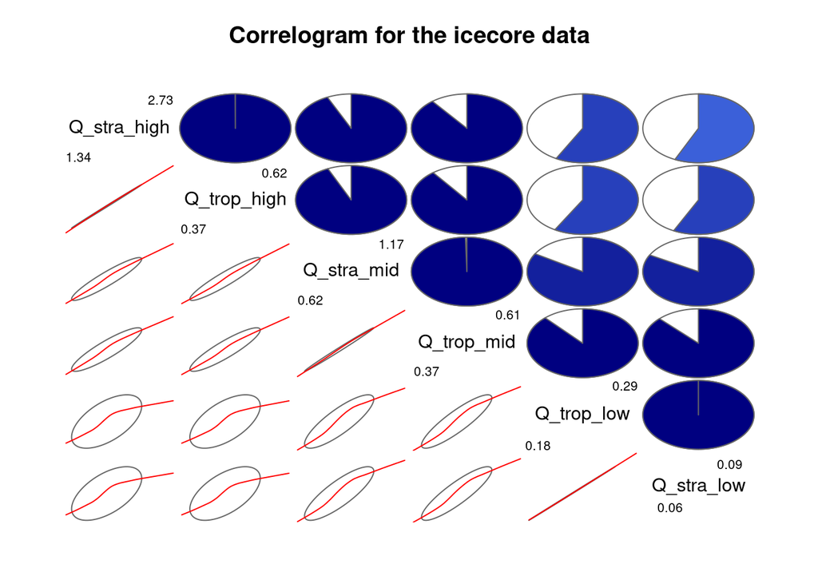

```r
# removing ID variable and the dependent variables for now
varnames<- setdiff(names(icecore), c("age", "EDML", "GRIP"))
corrgram::corrgram(icecore[,varnames], order="PCA",
         main="Correlogram for the icecore data",
         lower.panel=panel.ellipse, upper.panel=panel.pie,
         diag.panel=panel.minmax, text.panel=panel.txt)
```

All independent variables are strongly correlated between themselves. Reordering by PCA identifies the groupings which make sense (by latitude).

## Missing values

There’s some missingness in the data. Let’s have a look

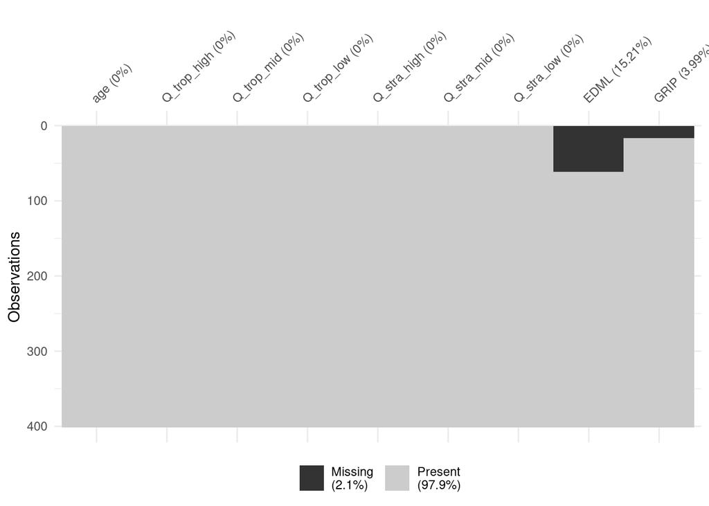

```r
naniar::vis_miss(icecore)
```

The missingness is present only in the response variables EDML and GRIP and only the fist few observations, i.e. it is missing not-at-random.

## Time aspect

We will take somewhat closer look at the time series aspect of the data. First of all, since this is the geology-related data, the age is measured backwards, which means that age=0 is actually the last (most recent) observation. Is the age equally spaced? Yes, it is equi-spaced by 20 years.

```r
unique(diff(icecore$age))
```

```
## [1] 20
```

Let’s rearrange the data and add an index. We will turn this tibble into the time series object (using class `tsibble`).

```r
icecore_df <- icecore %>%
  mutate(time=-age, .before = 1) %>%
  select(-age) %>%
  arrange(time)
```

Lets plot the response variables

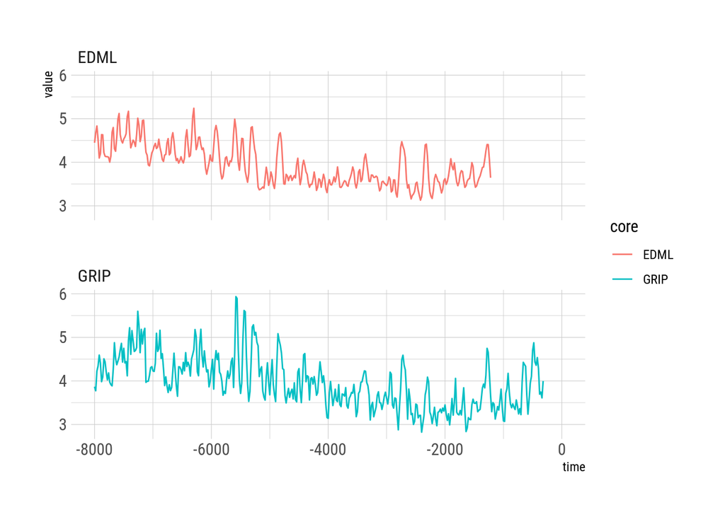

```r
icecore_df %>%
  select(time, EDML, GRIP) %>%
  pivot_longer(-time, names_to="core", values_to="value") %>%
  ggplot()+
  geom_line(aes(time,value, color=core))+
  facet_wrap(vars(core), ncol=1)
```

There does not appear to be a clear seasonality (after all the data is sampled every 20 years), but we can clearly see that there’s a trend.

# Train-test split

First, we will create the training and test set, separating the period for which we dont have the response variable, but have the predictor variables

```r
idx_GRIP_train <- !is.na(icecore_df$GRIP)
idx_EDML_train <- !is.na(icecore_df$EDML)

GRIP_train_ts <- icecore_df %>%
  select(-EDML) %>%
  filter(idx_GRIP_train) %>%
  as_tsibble(index = time)
GRIP_test_ts <- icecore_df %>%
  select(-GRIP, -EDML) %>%
  filter(!idx_GRIP_train) %>%
  as_tsibble(index = time)

EDML_train_ts <- icecore_df %>%
  select(-GRIP) %>%
  filter(idx_EDML_train) %>%
  as_tsibble(index = time)
EDML_test_ts <- icecore_df %>%
  select(-GRIP, -EDML) %>%
  filter(!idx_EDML_train) %>%
  as_tsibble(index = time)
```

# Greenland (GRIP) ice core

## Simple Forecasting

```r
trend_mod_GRIP <- GRIP_train_ts %>%
  model(linear=TSLM(GRIP ~trend()),
        piecewise=TSLM(GRIP~trend(knots=c(-7200,-2200)))
        )

fc_trend_mod_GRIP <- trend_mod_GRIP %>%
  fabletools::forecast(h=20)
```

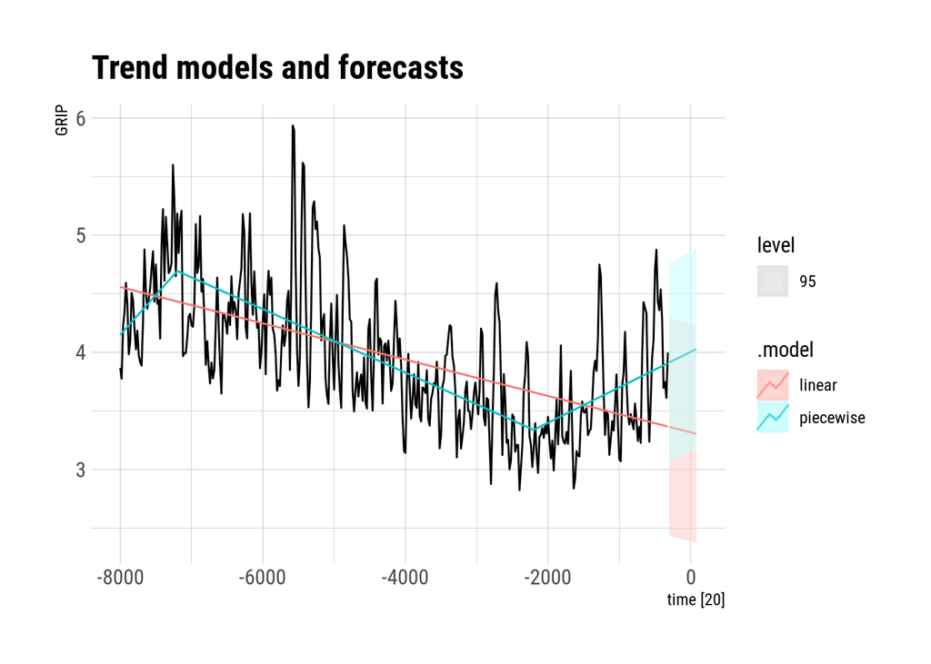

```r
GRIP_train_ts %>%
  autoplot(GRIP)+
  geom_line(data=fitted(trend_mod_GRIP),
            aes(y=.fitted, color=.model))+
  autolayer(fc_trend_mod_GRIP, alpha=0.6, level=95)+
  labs(title="Trend models and forecasts")
```

## Smoothing

Lets try some time series smoothing First, here’s a 9 period moving average. Pretty strong trend.

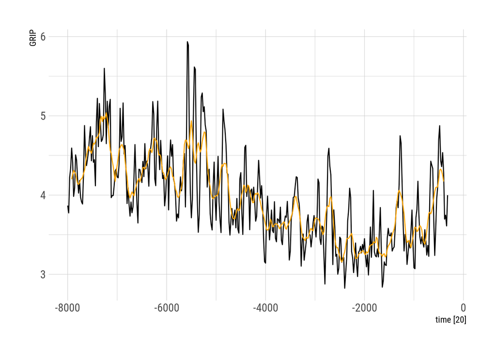

```r
GRIP_train_ts %>%
  mutate(`GRIP-9-MA`=slider::slide_dbl(GRIP, mean,
             .before=4, .after=4, .complete=TRUE)) %>%
  autoplot(GRIP)+
  geom_line(aes(y=`GRIP-9-MA`), color="orange")
```

Right now all 9 points in the smoothing window are equally weighted. Exponential smoothing creates a kernel of weights which attenuate away from the current point backward. Here’s a model with simple exponential smoothing.

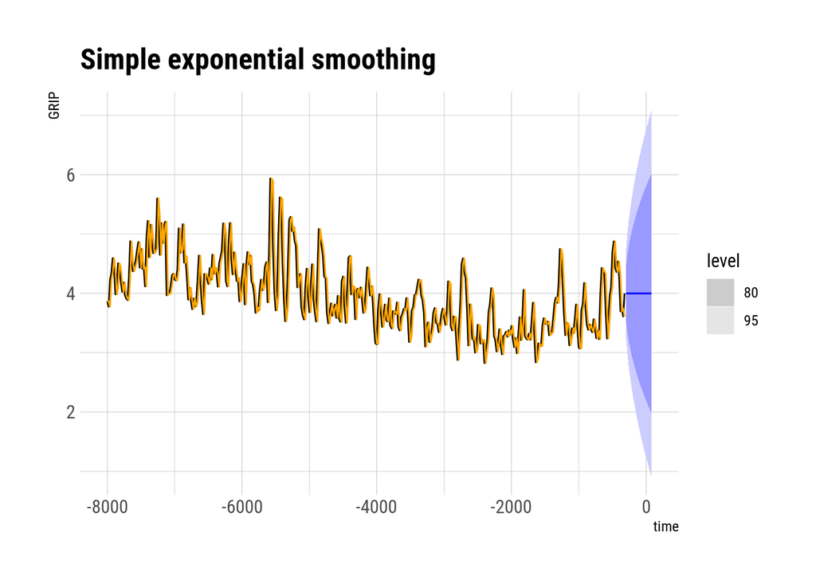

```r
es_mod_GRIP <- GRIP_train_ts %>%
  model(ETS(GRIP~error("A")+trend("N")))
fc_es_mod_GRIP <- es_mod_GRIP %>%
  fabletools::forecast(h=20)

fc_es_mod_GRIP %>%
  autoplot(GRIP_train_ts)+
  geom_line(data=augment(es_mod_GRIP),aes(y=.fitted), col="orange")+
  labs(title="Simple exponential smoothing")
```

Let’s try and incorporate the trend. This is using Holt’s linear trend method.

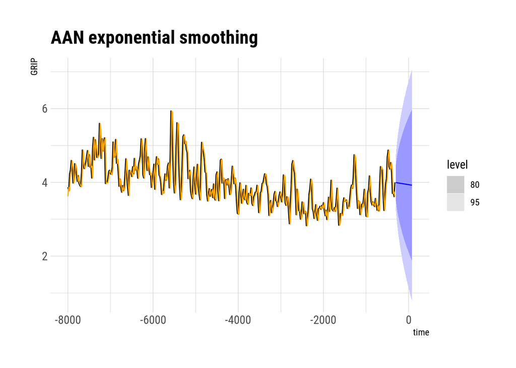

```r
es_mod_GRIP <- GRIP_train_ts %>%
  model(AAN=ETS(GRIP~error("A")+trend("A")))
fc_es_mod_GRIP <- es_mod_GRIP %>%
  fabletools::forecast(h=20)

fc_es_mod_GRIP %>%
  autoplot(GRIP_train_ts)+
  geom_line(data=augment(es_mod_GRIP),aes(y=.fitted), col="orange")+
  labs(title="AAN exponential smoothing")
```

As you can see the forecast picked up the downward sloping global linear trend.

Damped linear trend method corrects the infinite Holt’s trend projected into the future and instead attenuates the trend towards a flat line in the remote future. Let’s add it and compare.

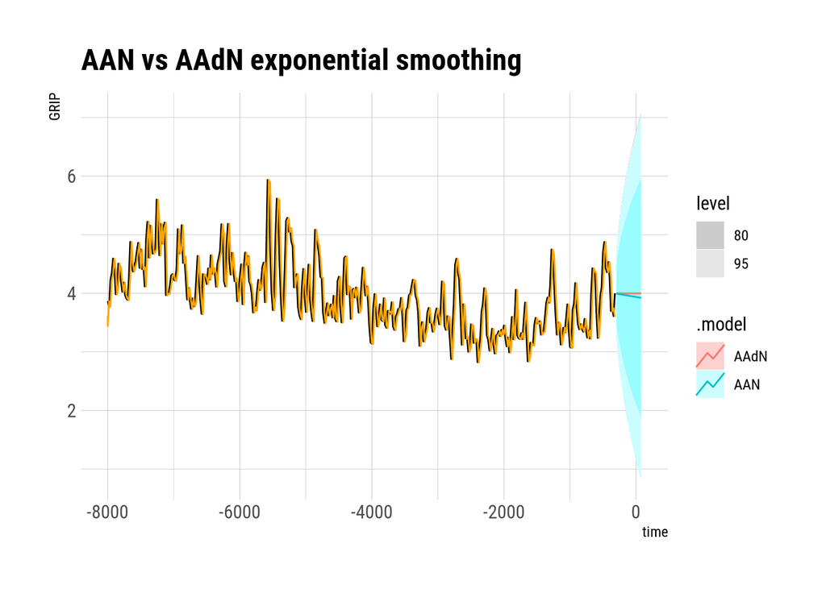

```r
es_mod_GRIP <- GRIP_train_ts %>%
  model(AAN=ETS(GRIP~error("A")+trend("A")),
        AAdN=ETS(GRIP~error("A")+trend("Ad", phi=0.9)))
fc_es_mod_GRIP <- es_mod_GRIP %>%
  fabletools::forecast(h=20)

fc_es_mod_GRIP %>%
  autoplot(GRIP_train_ts)+
  geom_line(data=augment(es_mod_GRIP),aes(y=.fitted), col="orange")+
  labs(title="AAN vs AAdN exponential smoothing")
```

## Time series regression

Let’s try to build a regression model. The time-indexed regression model of the form

$$y_t=\beta_0+\beta_1x_{1,t}+\beta_2x_{2,t}+\dots+\beta_kx_{k,t}+\varepsilon_t.$$

It makes the following assumptions about the errors $(\varepsilon_1,\varepsilon_2,\dots,\varepsilon_T)$:

- errors are unbiased (having a mean of zero)
- errors are not autocorrelated (there’s no remaining trend)
- errors are not related to the preditors (all signal has been extracted)
- errors are normally distributed with constant variance (for the purposes of making predictive intervals)

```r
all_mod_GRIP  <- GRIP_train_ts %>%
  model(TSLM(GRIP~Q_trop_high+Q_trop_mid+Q_trop_low+
               Q_stra_high+Q_stra_mid+Q_stra_low))
report(all_mod_GRIP)
```

```
## Series: GRIP
## Model: TSLM
##
## Residuals:
##      Min       1Q   Median       3Q      Max
## -0.76789 -0.22535 -0.01726  0.19074  1.18938
##
## Coefficients:
##             Estimate Std. Error t value Pr(>|t|)
## (Intercept)    5.151      3.816   1.350    0.178
## Q_trop_high -118.645     78.718  -1.507    0.133
## Q_trop_mid   259.711    187.770   1.383    0.167
## Q_trop_low  -442.566    351.375  -1.260    0.209
## Q_stra_high   20.285     12.843   1.579    0.115
## Q_stra_mid   -87.582     63.651  -1.376    0.170
## Q_stra_low   978.398    783.482   1.249    0.213
##
## Residual standard error: 0.3396 on 378 degrees of freedom
## Multiple R-squared: 0.6676,  Adjusted R-squared: 0.6623
## F-statistic: 126.5 on 6 and 378 DF, p-value: < 2.22e-16
```

None of the predictors is significant. How nice! Let’s see the predicted values

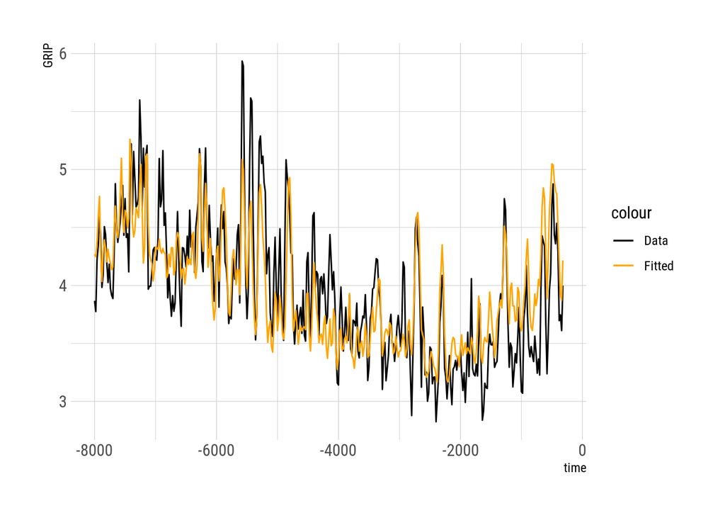

```r
augment(all_mod_GRIP) %>%
  ggplot(aes(x=time))+
  geom_line(aes(y=GRIP, color="Data"))+
  geom_line(aes(y=.fitted, color="Fitted"))+
  scale_color_manual(values=c(Data="black", Fitted="orange"))
```

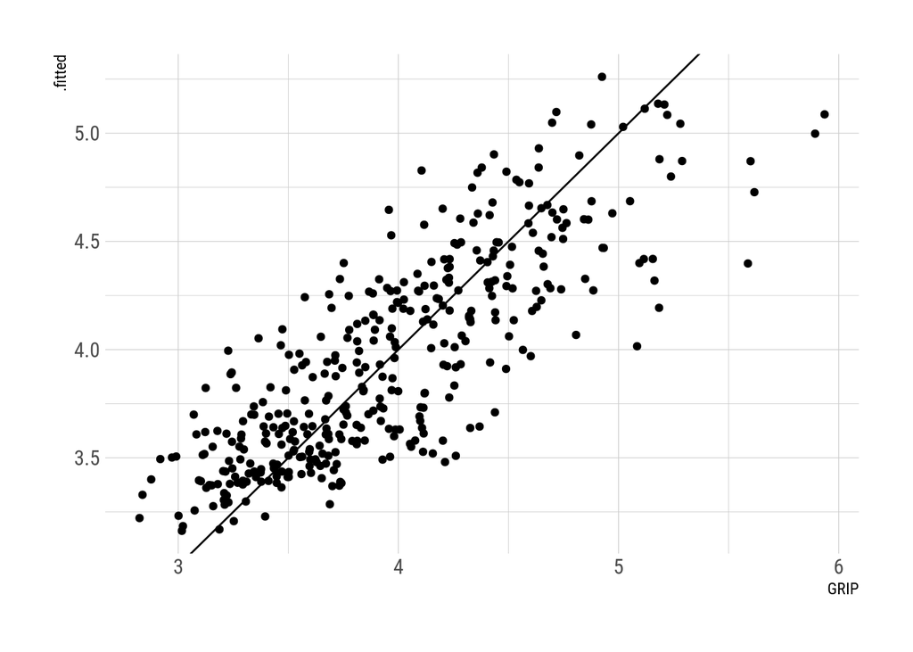

```r
augment(all_mod_GRIP) %>%
  ggplot(aes(x=GRIP,y=.fitted))+
  geom_point()+
  geom_abline(intercept = 0, slope = 1)
```

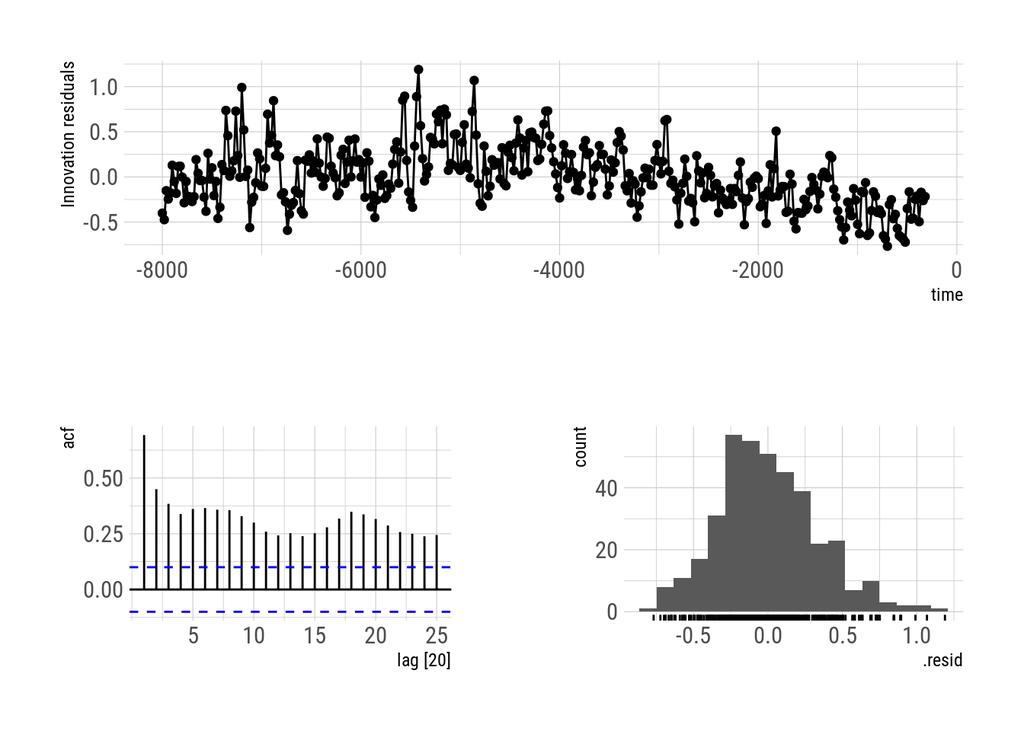

```r
all_mod_GRIP %>% gg_tsresiduals()
```

The plot shows significant autocorrelation in the residuals. We can try and plot the residuals against the covariates.

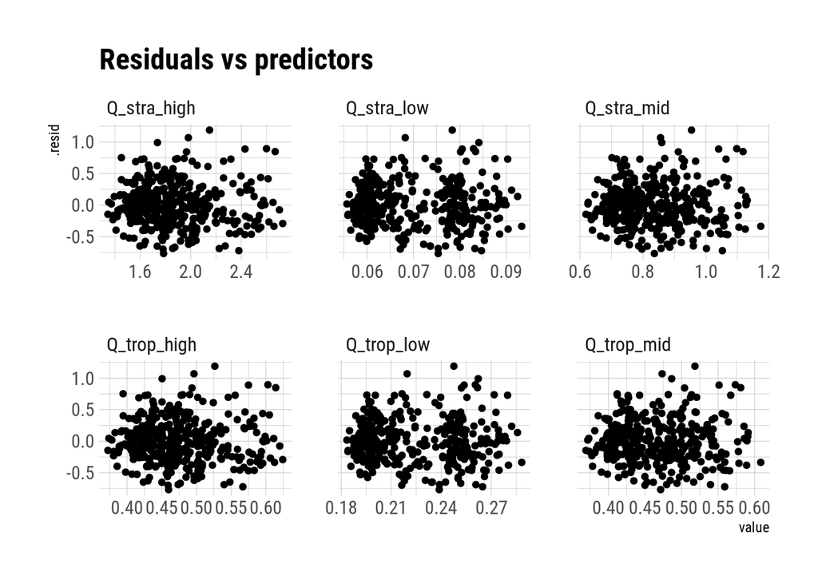

```r
icecore_df %>%
  left_join(residuals(all_mod_GRIP), by="time") %>%
  pivot_longer(starts_with("Q_"), names_to = "covariate", values_to="value") %>%
  ggplot(aes(x=value, y=.resid))+
  geom_point()+
  facet_wrap(vars(covariate), scales = "free_x")+
  labs(title="Residuals vs predictors")
```

Lets plot our residuals against the fitted values

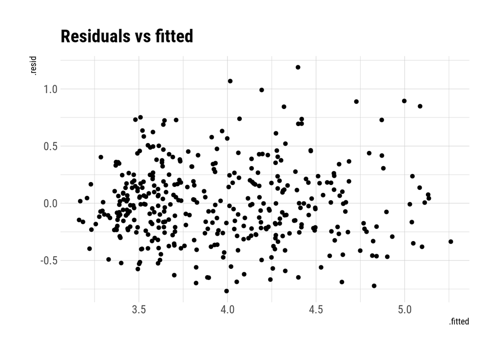

```r
augment(all_mod_GRIP) %>%
  ggplot(aes(x=.fitted, y=.resid))+
  geom_point()+labs(title="Residuals vs fitted")
```

```r
glance(all_mod_GRIP) %>%
  select(adj_r_squared, CV, AIC, AICc, BIC)
```

```
## # A tibble: 1 × 5
##   adj_r_squared    CV   AIC  AICc   BIC
##           <dbl> <dbl> <dbl> <dbl> <dbl>
## 1         0.662 0.118 -823. -822. -791.
```

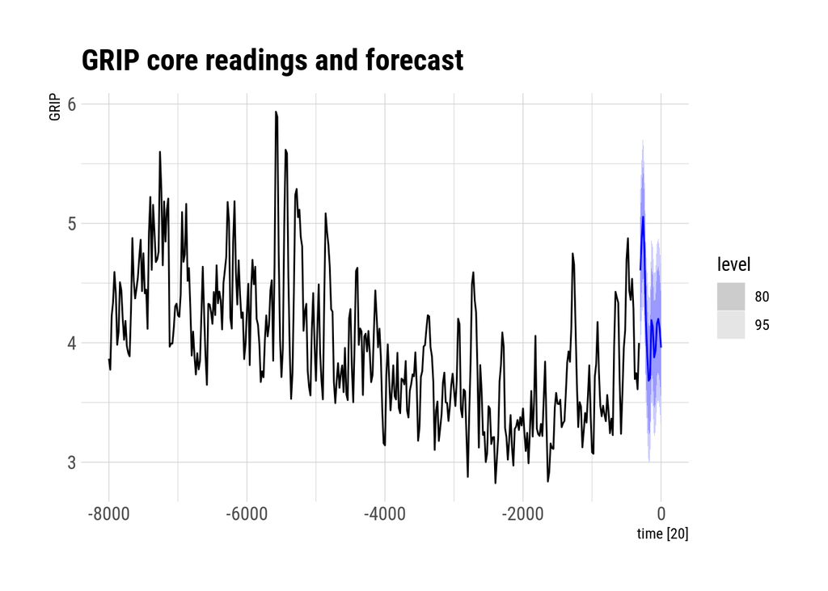

```r
fc_all_mod_GRIP <- fabletools::forecast(all_mod_GRIP,
                                        new_data=GRIP_test_ts)
GRIP_train_ts %>%
  autoplot(GRIP)+
  autolayer(fc_all_mod_GRIP)+
  labs(title="GRIP core readings and forecast")
```

## ARIMA regression

There seems to be quite a lot of signal left in the error term of our regression. We can try to extract this signal by fitting an ARIMA model to the residuals. Let’s start with a single covariate:

$$y_t=\beta_0+\beta_1x_t+\eta_t$$

where $\eta_t$ is an ARIMA model. The order of the model can be specified explicitly, but can also be left up to the engine to select.

```r
ARIMA_mod_GRIP <- GRIP_train_ts %>%
  model(ARIMA(GRIP~Q_stra_high))
report(ARIMA_mod_GRIP)
```

```
## Series: GRIP
## Model: LM w/ ARIMA(2,1,2) errors
##
## Coefficients:
##           ar1     ar2      ma1      ma2  Q_stra_high
##       -0.0234  0.2080  -0.2503  -0.6374       1.1532
## s.e.   0.1439  0.1108   0.1279   0.1246       0.0640
##
## sigma^2 estimated as 0.05513:  log likelihood=13.46
## AIC=-14.92   AICc=-14.7   BIC=8.78
```

The function picked the linear model with ARIMA(2,1,2) errors for us. Note that the intercept is gone due to the differencing. The way we can interpret these coefficients is:

$$\begin{gathered}
y_t=1.153x_t+ \eta_t,\\
\eta_t=-0.023\eta_{t-1}+0.2080\eta_{t-2}+\varepsilon_t-0.2503\varepsilon_{t-1}-0.6374\varepsilon_{t-2},\\
\varepsilon_t \sim NID(0,0.05513)
\end{gathered}$$

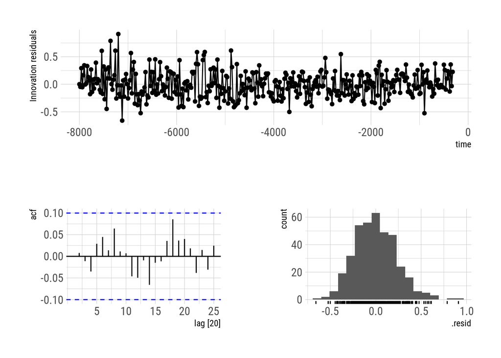

```r
ARIMA_mod_GRIP %>% gg_tsresiduals()
```

```r
augment(ARIMA_mod_GRIP) %>%
  features(.innov, ljung_box, dof=3, lag=8)
```

```
## # A tibble: 1 × 3
##   .model                    lb_stat lb_pvalue
##   <chr>                       <dbl>     <dbl>
## 1 ARIMA(GRIP ~ Q_stra_high)    3.37     0.643
```

This is really good! The residuals looks nice and the forecast should be sensible. Lets predict!

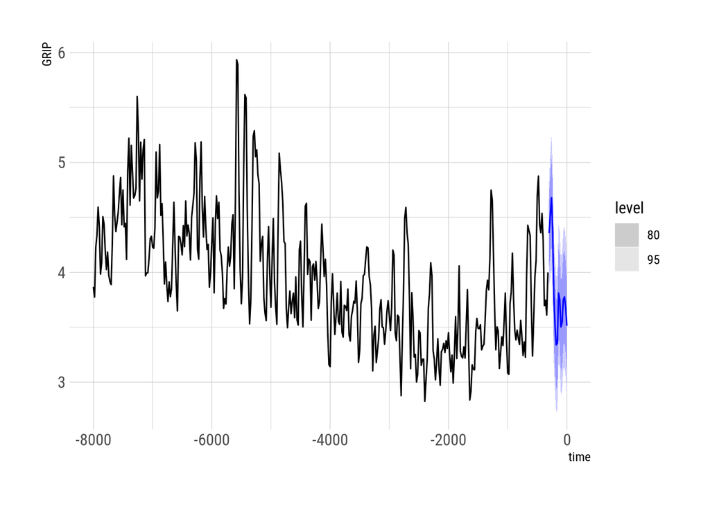

```r
fabletools::forecast(ARIMA_mod_GRIP, new_data=GRIP_test_ts) %>%
  autoplot(GRIP_train_ts)+
  labs("ARIMA regression forecast")
```

We should now see if we can improve the goodness of fit by adding more covariates. As you can remember from the correlogram plot, the covariates from the same latitude (high, med, low) vere strongly correlated. Perhaps we could add only one of each.

```r
ARIMA_mods <-GRIP_train_ts %>%
  model("stra_high"=ARIMA(GRIP~Q_stra_high),
        "trop_high"=ARIMA(GRIP~Q_trop_high),
        "all_stra"=ARIMA(GRIP~Q_stra_high+Q_stra_mid+Q_stra_low),
        "all_trop"=ARIMA(GRIP~Q_trop_high+Q_trop_mid+Q_trop_low),
        "all_high"=ARIMA(GRIP~Q_trop_high+Q_stra_high),
        "all_highmid"=ARIMA(GRIP~Q_trop_high+Q_stra_high+Q_trop_mid+Q_stra_mid),
        "all_highlow"=ARIMA(GRIP~Q_trop_high+Q_stra_high+Q_trop_low+Q_stra_low),
        "all"=ARIMA(GRIP~Q_trop_high+Q_stra_high+Q_trop_mid+Q_stra_mid+Q_stra_low+Q_trop_low)
        )
glance(ARIMA_mods)
```

```
## # A tibble: 8 × 8
##   .model      sigma2 log_lik   AIC  AICc   BIC ar_roots  ma_roots
##   <chr>        <dbl>   <dbl> <dbl> <dbl> <dbl> <list>    <list>
## 1 stra_high   0.0551    13.5 -14.9 -14.7  8.78 <cpl [2]> <cpl [2]>
## 2 trop_high   0.0553    12.9 -13.7 -13.5  9.97 <cpl [2]> <cpl [2]>
## 3 all_stra    0.0540    18.3 -20.6 -20.2 11.0  <cpl [2]> <cpl [2]>
## 4 all_trop    0.0542    17.7 -19.3 -18.9 12.3  <cpl [2]> <cpl [2]>
## 5 all_high    0.0553    13.5 -13.0 -12.7 14.6  <cpl [2]> <cpl [2]>
## 6 all_highmid 0.0541    18.4 -18.8 -18.3 16.8  <cpl [2]> <cpl [2]>
## 7 all_highlow 0.0541    18.5 -18.9 -18.5 16.6  <cpl [2]> <cpl [2]>
## 8 all         0.0544    18.6 -15.1 -14.4 28.3  <cpl [2]> <cpl [2]>
```

Lets look at the “Allhigh” model details.

```r
GRIP_allhigh_mod <- select(ARIMA_mods, "all_high")

GRIP_allhigh_mod %>% report()
```

```
## Series: GRIP
## Model: LM w/ ARIMA(2,1,2) errors
##
## Coefficients:
##           ar1     ar2      ma1      ma2  Q_trop_high  Q_stra_high
##       -0.0214  0.2059  -0.2531  -0.6347      -2.3829       1.5881
## s.e.   0.1460  0.1121   0.1304   0.1269       7.6652       1.4004
##
## sigma^2 estimated as 0.05527:  log likelihood=13.51
## AIC=-13.02   AICc=-12.72   BIC=14.63
```

Lets look at the residuals.

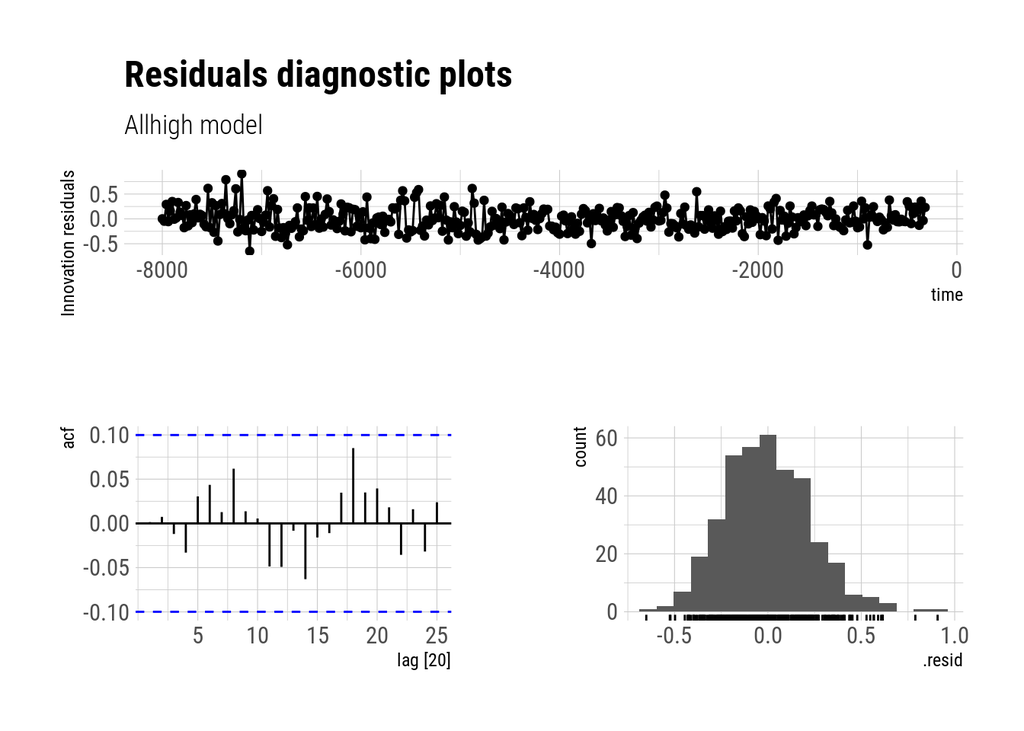

```r
gg_tsresiduals(GRIP_allhigh_mod)+
  labs(title="Residuals diagnostic plots",
       subtitle = "Allhigh model")
```

Just awesome! No autocorrelation in residuals, nice distribution. No obvious pattern. A few more diagnostic plots to check the residuals.

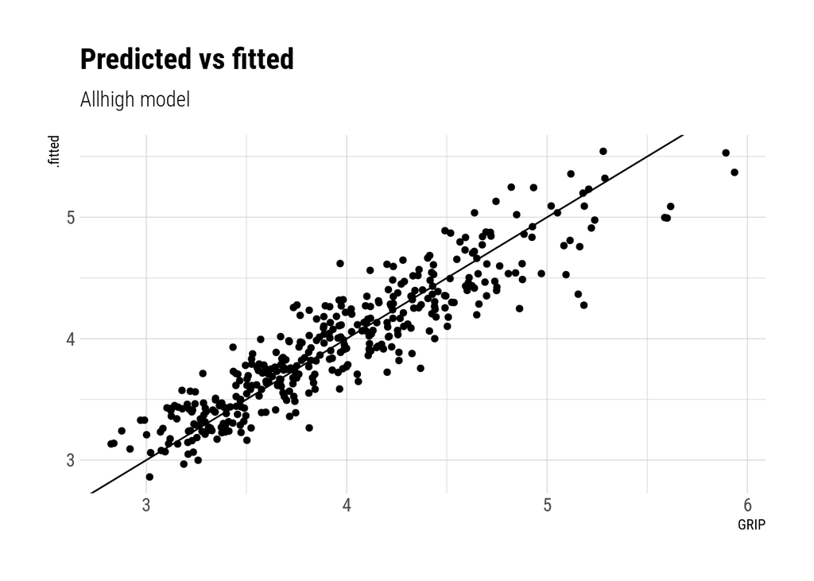

```r
augment(GRIP_allhigh_mod) %>%
  ggplot(aes(x=GRIP,y=.fitted))+
  geom_point()+
  geom_abline(intercept = 0, slope = 1)+
  labs(title="Predicted vs fitted",
       subtitle = "Allhigh model")
```

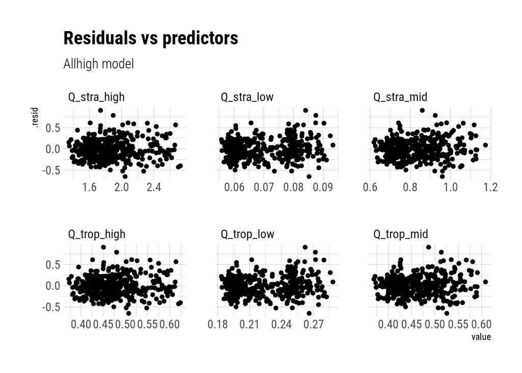

```r
icecore_df %>%
  left_join(residuals(GRIP_allhigh_mod), by="time") %>%
  pivot_longer(starts_with("Q_"), names_to = "covariate", values_to="value") %>%
  ggplot(aes(x=value, y=.resid))+
  geom_point()+
  facet_wrap(vars(covariate), scales = "free_x")+
  labs(title="Residuals vs predictors", subtitle = "Allhigh model")
```

Lets plot our residuals against the fitted values

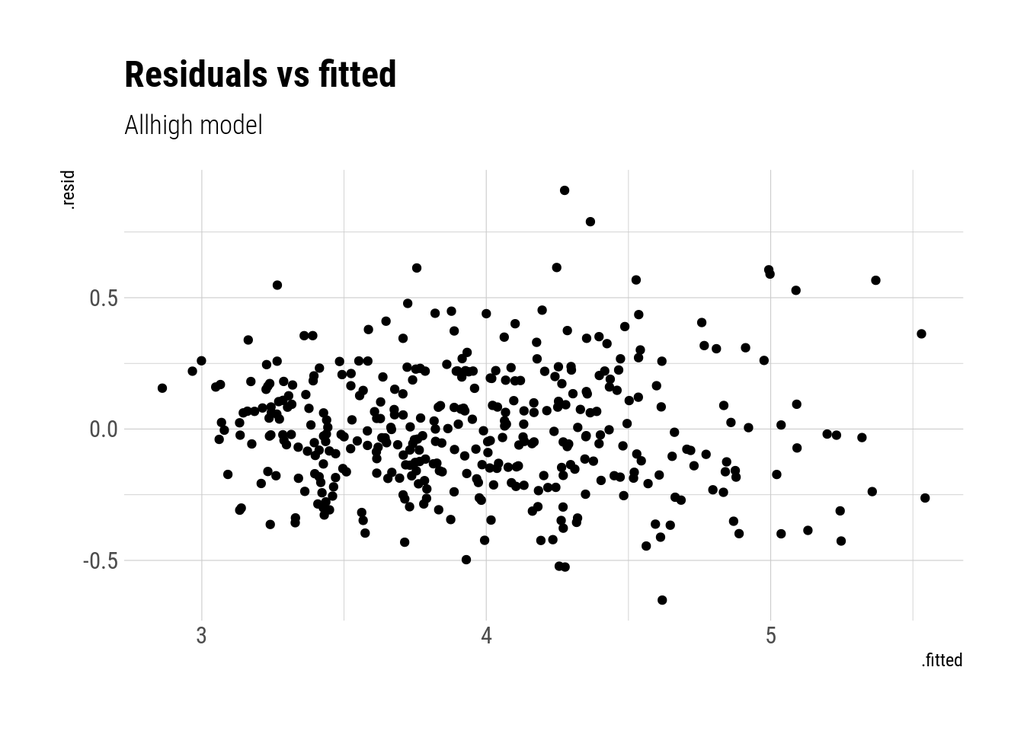

```r
augment(GRIP_allhigh_mod) %>%
  ggplot(aes(x=.fitted, y=.resid))+
  geom_point()+labs(title="Residuals vs fitted", subtitle = "Allhigh model")
```

No particular pattern here. All good, it seems.

## Cross-validation

We will use time series cross-validation to decide which model to use for prediction. We cross-validate the performance of the simple “Strahigh” model against the more complex “Allhigh”.

```r
GRIP_train_stretched <- GRIP_train_ts %>%
  stretch_tsibble(.init=100, .step=50)
GRIP_cv_mod <- GRIP_train_stretched %>%
  model("strahigh"=ARIMA(GRIP~0+pdq(2,1,2)+Q_stra_high),
        "allhigh"=ARIMA(GRIP~0+pdq(2,1,2)+Q_stra_high+Q_trop_high))
```

We now prepare the validation sets and predict on them, calculating the performance. We will predict 16 observations at a time (the size of our test set).

```r
GRIP_cv_valid_ts <- new_data(GRIP_train_stretched, n=16) %>%
  left_join(GRIP_train_ts, by="time")

GRIP_cv_mod_fc <- fabletools::forecast(GRIP_cv_mod, new_data=GRIP_cv_valid_ts) %>%
  group_by(.id, .model) %>%
  mutate(h=row_number()) %>%
  ungroup() %>%
  as_fable(response="GRIP", distribution=GRIP)

GRIP_cv_mod_fc %>%
  fabletools::accuracy(GRIP_train_ts, by=c("h", ".model")) %>%
  group_by(.model, .type) %>%
  summarize_all(mean)
```

```
## # A tibble: 2 × 11
## # Groups:   .model [2]
##   .model   .type     h     ME  RMSE   MAE   MPE  MAPE  MASE RMSSE   ACF1
##   <chr>    <chr> <dbl>  <dbl> <dbl> <dbl> <dbl> <dbl> <dbl> <dbl>  <dbl>
## 1 allhigh  Test    8.5 -0.153 0.316 0.267 -4.34  7.12 0.981 0.895 -0.128
## 2 strahigh Test    8.5 -0.149 0.309 0.259 -4.21  6.91 0.954 0.876 -0.127
```

The original model is better in every respect! BIC was right (as always).

Let’s predict using the `Q_stra_high` variable.

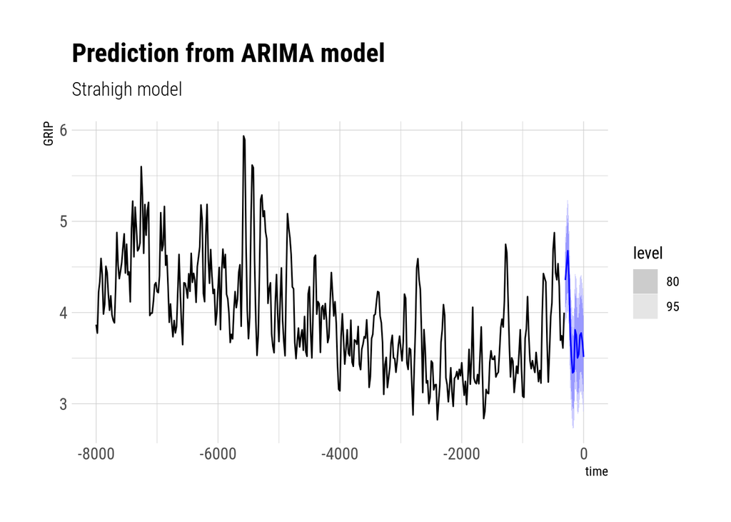

```r
ARIMA_mod_GRIP %>%
  fabletools::forecast(new_data=GRIP_test_ts) %>%
  autoplot(GRIP_train_ts)+
  labs(title="Prediction from ARIMA model",
       subtitle="Strahigh model")
```

# Antarctica (EDML) ice core

## ARIMA regression

Let’s save ourselves some time and go straight to the ARIMA regression for EDML response variable

```r
all_mod_EDML <- EDML_train_ts %>%
  model("stra_low"=ARIMA(EDML~Q_stra_low),
        "trop_low"=ARIMA(EDML~Q_trop_low),
        "all_stra"=ARIMA(EDML~Q_stra_high+Q_stra_mid+Q_stra_low),
        "all_trop"=ARIMA(EDML~Q_trop_high+Q_trop_mid+Q_trop_low),
        "all_low"=ARIMA(EDML~Q_stra_low+Q_trop_low),
        "all_lowmid"=ARIMA(EDML~Q_stra_low+Q_trop_low+Q_stra_mid+Q_trop_mid),
        "all_lowhigh"=ARIMA(EDML~Q_stra_low+Q_trop_low+Q_stra_high+Q_trop_high),
        "all"=ARIMA(EDML~Q_stra_high+Q_stra_mid+Q_stra_low+
                      Q_trop_high+Q_trop_mid+Q_trop_low))
glance(all_mod_EDML)
```

```
## # A tibble: 8 × 8
##   .model      sigma2 log_lik   AIC  AICc   BIC ar_roots  ma_roots
##   <chr>        <dbl>   <dbl> <dbl> <dbl> <dbl> <list>    <list>
## 1 stra_low    0.0179    203. -393. -392. -366. <cpl [3]> <cpl [1]>
## 2 trop_low    0.0179    203. -392. -392. -365. <cpl [3]> <cpl [1]>
## 3 all_stra    0.0175    209. -396. -395. -354. <cpl [5]> <cpl [1]>
## 4 all_trop    0.0174    209. -397. -396. -355. <cpl [5]> <cpl [1]>
## 5 all_low     0.0174    209. -398. -397. -360. <cpl [4]> <cpl [2]>
## 6 all_lowmid  0.0176    208. -393. -392. -351. <cpl [4]> <cpl [2]>
## 7 all_lowhigh 0.0179    204. -390. -389. -355. <cpl [3]> <cpl [1]>
## 8 all         0.0174    211. -397. -396. -351. <cpl [3]> <cpl [1]>
```

Let’s pick one of them and look at the residuals.

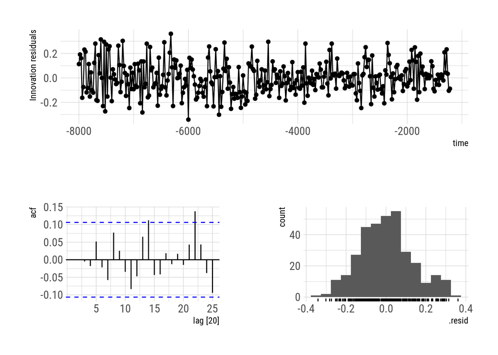

```r
all_mod_EDML %>% select("all_lowmid") %>%
  gg_tsresiduals()
```

Residuals look largely ok with only two periods “sticking out” of the confidence bands: at lags 14 and 22 (no obvious reason why). I am concerned about the non-stationary variance of the residuals and, therefore, slightly irregular shape of the error distribution.

```r
all_mod_EDML %>% select("all_lowmid") %>%
  report()
```

```
## Series: EDML
## Model: LM w/ ARIMA(4,0,2) errors
##
## Coefficients:
##          ar1      ar2     ar3      ar4      ma1      ma2  Q_stra_low
##       1.7300  -1.2167  0.5075  -0.1376  -0.1061  -0.6246   -117.4080
## s.e.  0.1142   0.1718  0.1495   0.0697   0.0971   0.0841     75.5956
##       Q_trop_low  Q_stra_mid  Q_trop_mid
##          57.0437     -0.9965      0.4834
## s.e.     30.6785      3.4000      9.4865
##
## sigma^2 estimated as 0.01762:  log likelihood=207.63
## AIC=-393.26   AICc=-392.46   BIC=-351.14
```

This is a pretty complex model: 4 covariates, 4 lags, and 2 moving averages.

The alternative model’s residuals

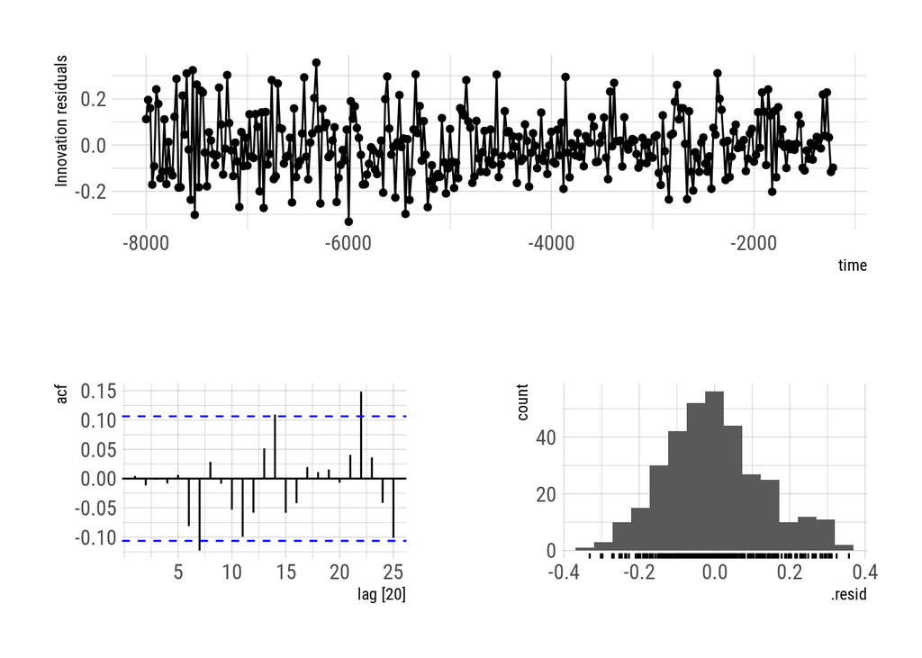

```r
all_mod_EDML %>% select("all_lowhigh") %>%
  gg_tsresiduals()
```

Here we have a significant autoregression at the lag 7 and 22.

```r
all_mod_EDML %>% select("all_lowhigh") %>%
  report()
```

```
## Series: EDML
## Model: LM w/ ARIMA(3,0,1) errors
##
## Coefficients:
##          ar1      ar2     ar3     ma1  Q_stra_low  Q_trop_low  Q_stra_high
##       0.8464  -0.3943  0.0530  0.7735   -163.4156     72.1986       0.3493
## s.e.  0.0807   0.0929  0.0665  0.0461     53.7200     19.3986       0.6953
##       Q_trop_high
##           -3.0112
## s.e.       4.0055
##
## sigma^2 estimated as 0.01791:  log likelihood=203.95
## AIC=-389.91   AICc=-389.36   BIC=-355.45
```

This is somewhat simpler model with 3 lags, 1 moving average and 4 variables.

## Cross-validation

We will employ the “stretching window” cross-validation scheme to assess the performance of the selected number of models on the training data (effectively treating part of it as a validation set). Here we will set the initial training set to be 100 observations and then at every iteration we will add 61 to the training set, always predicting 61 observations (equivalent to the size of the test set we are trying to predict).

```r
EDML_stretched <- EDML_train_ts %>%
  stretch_tsibble(.init=100, .step=61)
EDML_cv_mod <- EDML_stretched %>%
  model("all_lowmid"=ARIMA(EDML~0+pdq(4,0,2)+Q_stra_low+Q_trop_low+Q_stra_mid+Q_trop_mid),
        "all_lowhigh"=ARIMA(EDML~0+pdq(3,0,1)+Q_stra_low+Q_trop_low+Q_stra_high+Q_trop_high))
```

```r
EDML_cv_valid_ts <- new_data(EDML_stretched, n=61) %>%
  left_join(EDML_train_ts, by="time")

EDML_cv_mod_fc <- fabletools::forecast(EDML_cv_mod, new_data=EDML_cv_valid_ts) %>%
  group_by(.id, .model) %>%
  mutate(h=row_number()) %>%
  ungroup() %>%
  as_fable(response="EDML", distribution=EDML)

EDML_cv_mod_fc %>% fabletools::accuracy(EDML_train_ts, by=c("h", ".model")) %>%
  group_by(.model, .type) %>%
  summarize_all(mean)
```

```
## # A tibble: 2 × 11
## # Groups:   .model [2]
##   .model      .type     h     ME  RMSE   MAE   MPE  MAPE  MASE RMSSE   ACF1
##   <chr>       <chr> <dbl>  <dbl> <dbl> <dbl> <dbl> <dbl> <dbl> <dbl>  <dbl>
## 1 all_lowhigh Test     31 0.0293 0.273 0.223 0.277  5.77  1.31  1.26 -0.139
## 2 all_lowmid  Test     31 0.0777 0.290 0.245 1.62   6.35  1.44  1.34 -0.160
```

The “lowhigh” is slightly better on all metrics.

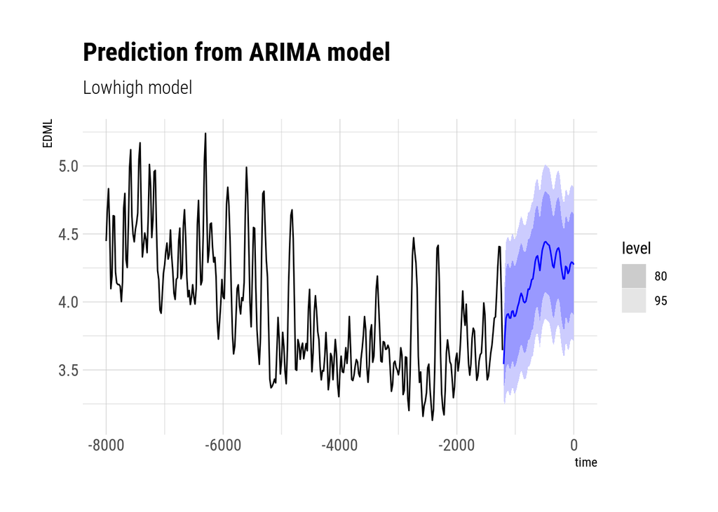

```r
all_mod_EDML %>% select(all_lowhigh) %>%
  fabletools::forecast(new_data=EDML_test_ts) %>%
  autoplot(EDML_train_ts)+
  labs(title="Prediction from ARIMA model",
       subtitle="Lowhigh model")
```